[O’Hara on GitHub](https://github.com/oharac)

# Create conservation priorities layers

Compiled on Thu Aug 22 07:56:55 2019 by ohara

```r
library(raster)
source('https://raw.githubusercontent.com/oharac/src/master/R/common.R')

source(here::here('common_fxns.R'))

dir_bd_anx <- '~/git-annex/bd_chi' ### this is on git-annex in home/ohara
dir_cons <- 'layers/cons_priorities'
```

# 1 Summary

Following Selig et al. 2014, estimate conservation priorities based on biodiversity metrics and threats.

- Identify top 10% and bottom 10% of cells based on cumulative impacts.
- Identify top 5% of cells based on species richness and range-rarity species richness, separately within EEZ and ABNJ.
- New: Identify top 5% and bottom 5% of cells based on mean biodiversity risk.
  - when intersecting with species richness, maybe up thresholds on both to 10%?
- New: Identify top 10% and bottom 10% of cells based on trends in CHI.
  - when intersecting with CHI, maybe up thresholds on both to 20%?

Intersect these various layers and see what magic occurs.

# 2 Data Sources

Halpern et al. 2019, O’Hara et al. 2019

# 3 Methods

## 3.1 Identify EEZ and ABNJ regions

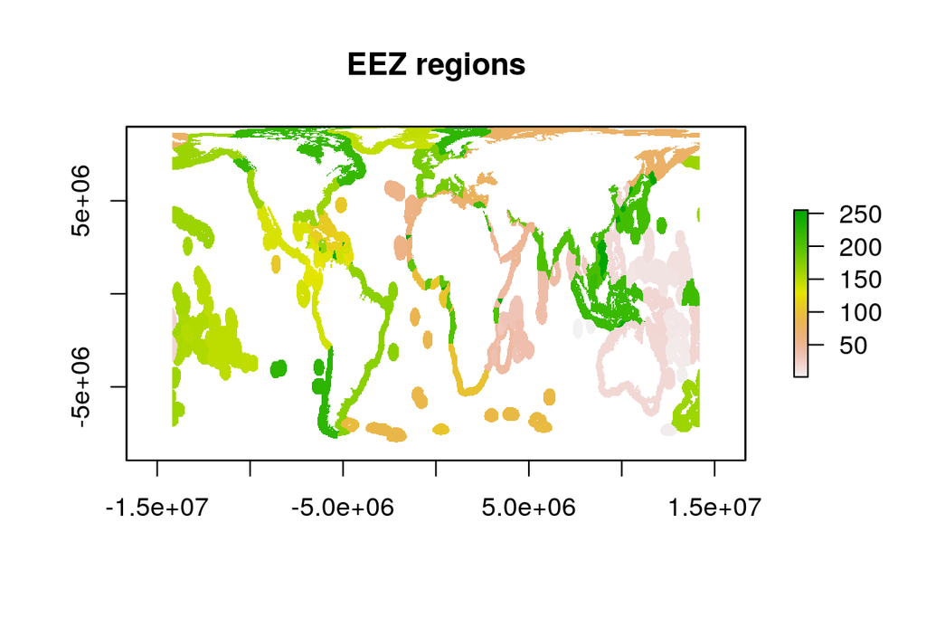

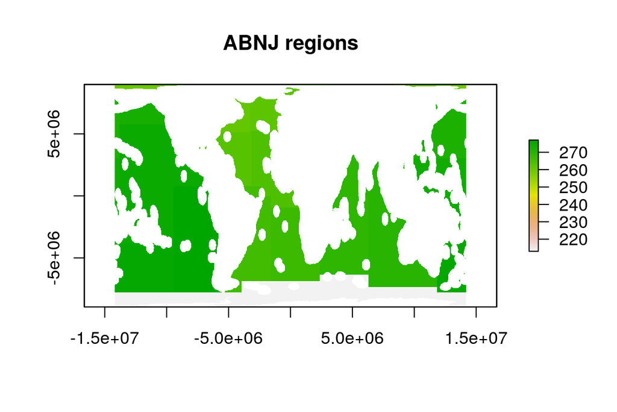

## 3.2 Identify top/bottom 10% and 20% of CHI and dCHI/dt

The function `classify_qtiles()` identifies thresholds separately for EEZ and ABNJ regions, calculates the quantiles for each region separately, then combines into a single raster. EEZ quantiles are positive, ABNJ are negative, just to help keep them separate.

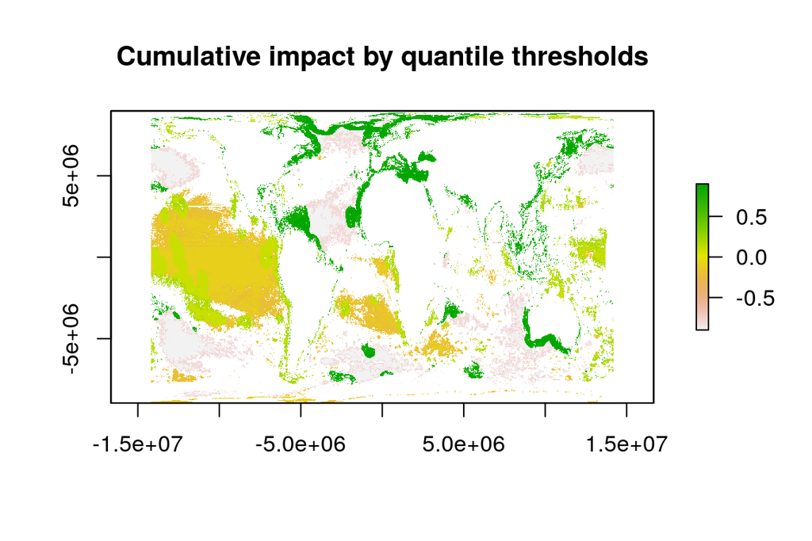

| 0.1 | 0.2 | 0.8 | 0.9 |
| --- | --- | --- | --- |
| 0.4802964 | 0.6901948 | 1.576264 | 1.92021 |

| 0.1 | 0.2 | 0.8 | 0.9 |
| --- | --- | --- | --- |
| 0.3210601 | 0.5314127 | 1.492434 | 1.84533 |

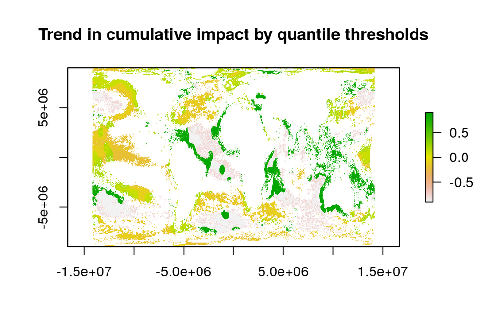

| 0.1 | 0.2 | 0.8 | 0.9 |
| --- | --- | --- | --- |
| -0.0200396 | 0.0019142 | 0.0867103 | 0.1089247 |

| 0.1 | 0.2 | 0.8 | 0.9 |
| --- | --- | --- | --- |
| -0.0126811 | 0.0023673 | 0.0875629 | 0.1187378 |

## 3.3 Identify top/bottom 5% and 10% of species richness, range-rarity SR

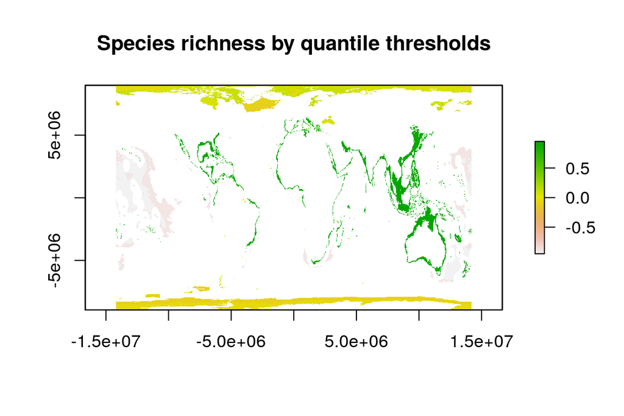

| 0.05 | 0.1 | 0.9 | 0.95 |
| --- | --- | --- | --- |
| 13 | 30 | 157 | 434 |

| 0.05 | 0.1 | 0.9 | 0.95 |
| --- | --- | --- | --- |
| 28 | 39 | 71 | 77 |

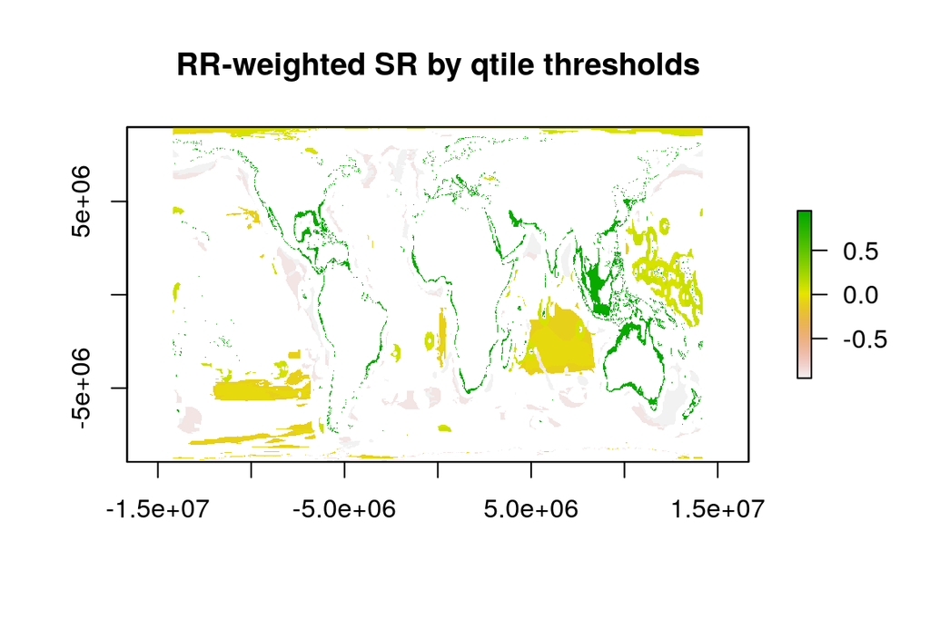

| 0.05 | 0.1 | 0.9 | 0.95 |
| --- | --- | --- | --- |
| 6e-07 | 7e-07 | 0.0001197 | 0.0002687 |

| 0.05 | 0.1 | 0.9 | 0.95 |
| --- | --- | --- | --- |
| 4e-07 | 5e-07 | 1.2e-06 | 1.4e-06 |

## 3.4 Identify top/bottom 5% and 10% of biodiversity risk (unweighted and RR-weighted)

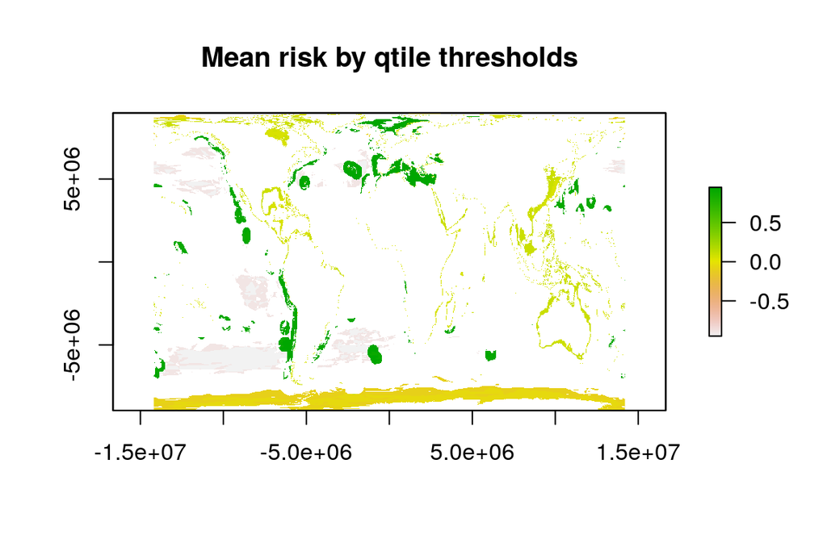

| 0.05 | 0.1 | 0.9 | 0.95 |
| --- | --- | --- | --- |
| 0.0869565 | 0.1070968 | 0.2083333 | 0.2204082 |

| 0.05 | 0.1 | 0.9 | 0.95 |
| --- | --- | --- | --- |
| 0.1090909 | 0.1361702 | 0.2346154 | 0.2421053 |

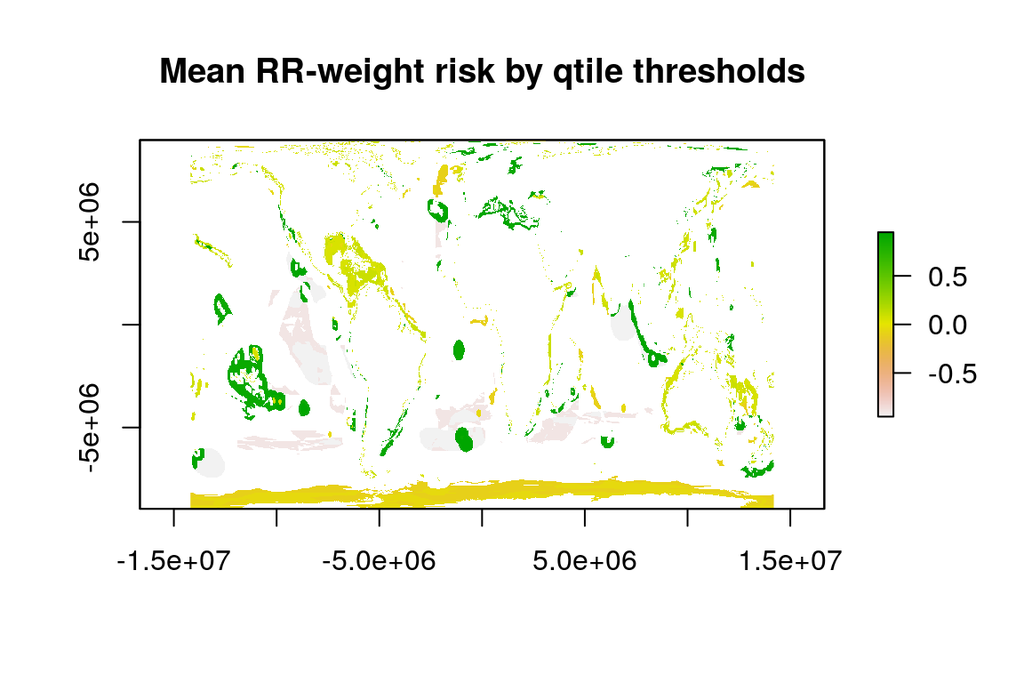

| 0.05 | 0.1 | 0.9 | 0.95 |
| --- | --- | --- | --- |
| 0.0249906 | 0.040345 | 0.2642578 | 0.2924945 |

| 0.05 | 0.1 | 0.9 | 0.95 |
| --- | --- | --- | --- |
| 0.0553441 | 0.0793087 | 0.3104548 | 0.3402006 |

## 3.5 Identify top/bottom 5% and 10% of % threatened (unweighted and RR-weighted)

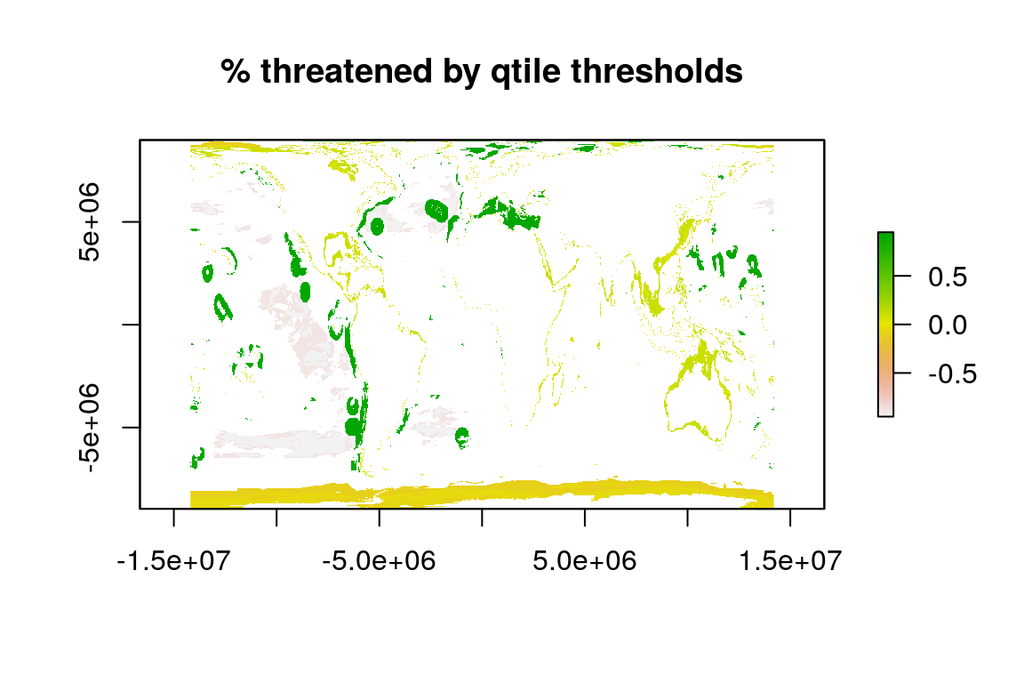

| 0.05 | 0.1 | 0.9 | 0.95 |
| --- | --- | --- | --- |
| 0.1411043 | 0.1722306 | 0.3809524 | 0.4038461 |

| 0.05 | 0.1 | 0.9 | 0.95 |
| --- | --- | --- | --- |
| 0.16 | 0.2272727 | 0.4366197 | 0.4482759 |

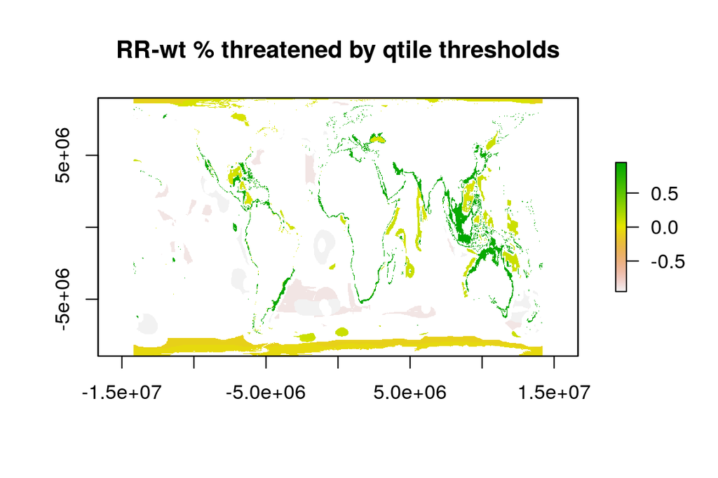

| 0.05 | 0.1 | 0.9 | 0.95 |
| --- | --- | --- | --- |
| 1e-07 | 2e-07 | 1.42e-05 | 3.17e-05 |

| 0.05 | 0.1 | 0.9 | 0.95 |
| --- | --- | --- | --- |
| 0 | 1e-07 | 4e-07 | 6e-07 |